```python
%load_ext autoreload
%autoreload 2
from pipeline import loader as lo
from pipeline import classifier as clas
from pipeline import explorer as ex
from pipeline import processor as pro
from pipeline import _util as ut
from pipeline import evaluator as ev
from pipeline import features_generator as fe
```

# Finacial Distress Prediction ( pipeline skeleton)

## 1. Load Data

#### - Load data from csv file

#### - Check the data type of each column

```python
df = lo.load()
```

```python
df.dtypes
```

```
PersonID                                  int64
SeriousDlqin2yrs                          int64
RevolvingUtilizationOfUnsecuredLines    float64
age                                       int64
zipcode                                   int64
NumberOfTime30-59DaysPastDueNotWorse      int64
DebtRatio                               float64
MonthlyIncome                           float64
NumberOfOpenCreditLinesAndLoans           int64
NumberOfTimes90DaysLate                   int64
NumberRealEstateLoansOrLines              int64
NumberOfTime60-89DaysPastDueNotWorse      int64
NumberOfDependents                      float64
dtype: object
```

## 2. Explore Data

### 1. show the summary statistics of the data

```python
ex.basic_sum(df)
```

|  | PersonID | SeriousDlqin2yrs | RevolvingUtilizationOfUnsecuredLines | age | zipcode | NumberOfTime30-59DaysPastDueNotWorse | DebtRatio | MonthlyIncome | NumberOfOpenCreditLinesAndLoans | NumberOfTimes90DaysLate | NumberRealEstateLoansOrLines | NumberOfTime60-89DaysPastDueNotWorse | NumberOfDependents |
| --- | --- | --- | --- | --- | --- | --- | --- | --- | --- | --- | --- | --- | --- |
| count | 41016.000000 | 41016.000000 | 41016.00000 | 41016.000000 | 41016.000000 | 41016.000000 | 41016.000000 | 3.304200e+04 | 41016.000000 | 41016.000000 | 41016.000000 | 41016.000000 | 39979.000000 |
| mean | 115800.154598 | 0.161400 | 6.37587 | 51.683489 | 60623.824166 | 0.589233 | 331.458137 | 6.578996e+03 | 8.403477 | 0.419592 | 1.008801 | 0.371587 | 0.773231 |
| std | 28112.723511 | 0.367904 | 221.61895 | 14.746880 | 11.984357 | 5.205628 | 1296.109695 | 1.344683e+04 | 5.207324 | 5.190382 | 1.153826 | 5.169641 | 1.121269 |
| min | 22.000000 | 0.000000 | 0.00000 | 21.000000 | 60601.000000 | 0.000000 | 0.000000 | 0.000000e+00 | 0.000000 | 0.000000 | 0.000000 | 0.000000 | 0.000000 |
| 25% | 106539.750000 | 0.000000 | 0.03431 | 41.000000 | 60618.000000 | 0.000000 | 0.176375 | 3.333000e+03 | 5.000000 | 0.000000 | 0.000000 | 0.000000 | 0.000000 |
| 50% | 119901.500000 | 0.000000 | 0.18973 | 51.000000 | 60625.000000 | 0.000000 | 0.369736 | 5.250000e+03 | 8.000000 | 0.000000 | 1.000000 | 0.000000 | 0.000000 |
| 75% | 134698.250000 | 0.000000 | 0.66716 | 62.000000 | 60629.000000 | 0.000000 | 0.866471 | 8.055750e+03 | 11.000000 | 0.000000 | 2.000000 | 0.000000 | 1.000000 |
| max | 149999.000000 | 1.000000 | 22000.00000 | 109.000000 | 60644.000000 | 98.000000 | 106885.000000 | 1.794060e+06 | 56.000000 | 98.000000 | 32.000000 | 98.000000 | 13.000000 |

### 2.show the distribution of each variable

```
<module 'matplotlib.pyplot' from '/home/pgw/miniconda3/envs/hw2_env/lib/python3.7/site-packages/matplotlib/pyplot.py'>
```

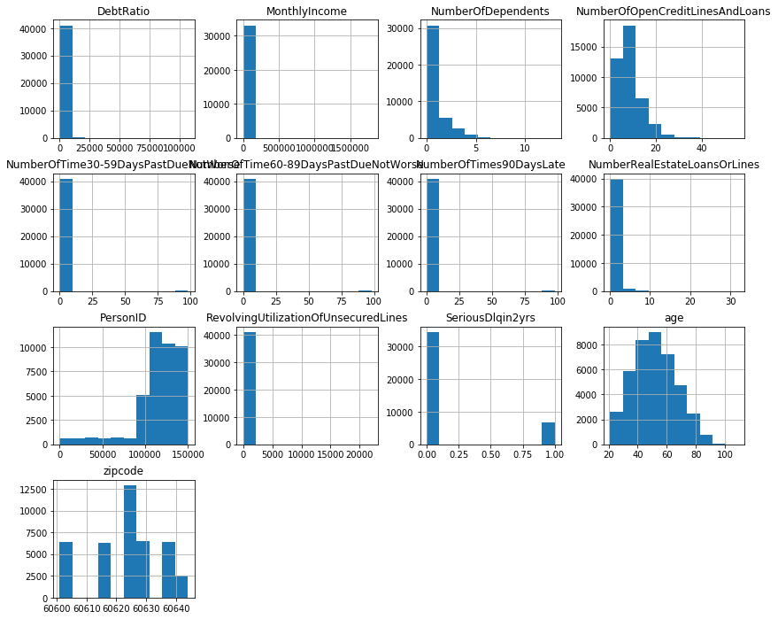

```python
ut.hist_some(df)
```

**Interpretation**:

From the distribution of the each variable, we can see that the variables except PersonID and Zipcode share the same kind of distribution with our output variable somehow. PersonID is just a index of one person, we may want to get rid of it. Since zipcode is a discrete variable, it may be a good idea to transform it into dummies.

### 3. Show the table of pair-wise correlation

```python
cor_table = ex.corr_df(df)
cor_table
```

|  | PersonID | SeriousDlqin2yrs | RevolvingUtilizationOfUnsecuredLines | age | zipcode | NumberOfTime30-59DaysPastDueNotWorse | DebtRatio | MonthlyIncome | NumberOfOpenCreditLinesAndLoans | NumberOfTimes90DaysLate | NumberRealEstateLoansOrLines | NumberOfTime60-89DaysPastDueNotWorse | NumberOfDependents |
| --- | --- | --- | --- | --- | --- | --- | --- | --- | --- | --- | --- | --- | --- |
| PersonID | 1.000000 | -0.622739 | 0.004499 | 0.108533 | -0.021010 | -0.082598 | 0.006864 | 0.019755 | 0.022669 | -0.076856 | 0.004341 | -0.065353 | -0.030364 |
| SeriousDlqin2yrs | -0.622739 | 1.000000 | -0.004586 | -0.173728 | -0.045051 | 0.149334 | -0.013502 | -0.032810 | -0.039898 | 0.139609 | -0.010641 | 0.121886 | 0.065708 |
| RevolvingUtilizationOfUnsecuredLines | 0.004499 | -0.004586 | 1.000000 | -0.008003 | 0.006009 | -0.001999 | 0.022250 | 0.005832 | -0.014590 | -0.001686 | 0.004763 | -0.001413 | 0.005342 |
| age | 0.108533 | -0.173728 | -0.008003 | 1.000000 | 0.005408 | -0.068696 | 0.038828 | 0.048138 | 0.159866 | -0.069036 | 0.049168 | -0.063622 | -0.211002 |
| zipcode | -0.021010 | -0.045051 | 0.006009 | 0.005408 | 1.000000 | -0.002424 | 0.002088 | -0.004980 | -0.009214 | -0.001487 | 0.003141 | -0.001198 | -0.001744 |
| NumberOfTime30-59DaysPastDueNotWorse | -0.082598 | 0.149334 | -0.001999 | -0.068696 | -0.002424 | 1.000000 | -0.011620 | -0.015224 | -0.070704 | 0.984465 | -0.037863 | 0.988530 | -0.007840 |
| DebtRatio | 0.006864 | -0.013502 | 0.022250 | 0.038828 | 0.002088 | -0.011620 | 1.000000 | -0.022988 | 0.082791 | -0.014790 | 0.177858 | -0.013290 | -0.070558 |
| MonthlyIncome | 0.019755 | -0.032810 | 0.005832 | 0.048138 | -0.004980 | -0.015224 | -0.022988 | 1.000000 | 0.107100 | -0.017954 | 0.127313 | -0.015336 | 0.060528 |
| NumberOfOpenCreditLinesAndLoans | 0.022669 | -0.039898 | -0.014590 | 0.159866 | -0.009214 | -0.070704 | 0.082791 | 0.107100 | 1.000000 | -0.098176 | 0.442776 | -0.087154 | 0.060218 |
| NumberOfTimes90DaysLate | -0.076856 | 0.139609 | -0.001686 | -0.069036 | -0.001487 | 0.984465 | -0.014790 | -0.017954 | -0.098176 | 1.000000 | -0.054661 | 0.992143 | -0.015737 |
| NumberRealEstateLoansOrLines | 0.004341 | -0.010641 | 0.004763 | 0.049168 | 0.003141 | -0.037863 | 0.177858 | 0.127313 | 0.442776 | -0.054661 | 1.000000 | -0.047996 | 0.114880 |
| NumberOfTime60-89DaysPastDueNotWorse | -0.065353 | 0.121886 | -0.001413 | -0.063622 | -0.001198 | 0.988530 | -0.013290 | -0.015336 | -0.087154 | 0.992143 | -0.047996 | 1.000000 | -0.016493 |
| NumberOfDependents | -0.030364 | 0.065708 | 0.005342 | -0.211002 | -0.001744 | -0.007840 | -0.070558 | 0.060528 | 0.060218 | -0.015737 | 0.114880 | -0.016493 | 1.000000 |

```
<module 'matplotlib.pyplot' from '/home/pgw/miniconda3/envs/hw2_env/lib/python3.7/site-packages/matplotlib/pyplot.py'>
```

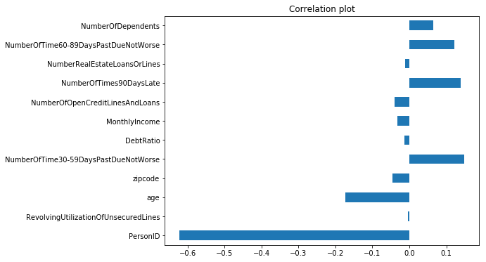

```python
ut.plot_corr(cor_table,'SeriousDlqin2yrs' )
```

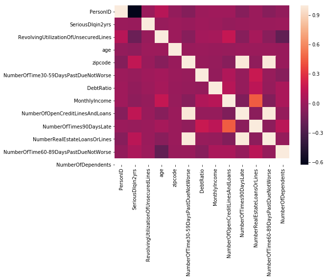

```python
ut.heat_corr(cor_table)
```

**Interpretation**:

From the table, the bar chart and the heatmap of the pair-wise correlation, we can tell that the PersonID is highly correlated with the output in the negtive direction. And it's almost uncorrelated with the other independent variable. There is not a good explaination for that, it's related to how to assign the personID to the person. We cannot get the conclusion like one-unit personID increase is associated with the probability decrease of SeriousDlqin2yrs. I think we can drop personID column.

There are a family of variable about the number of time past due time or worse, they are highly correlated in the positive direction, which make sence.

```python
df.drop('PersonID',axis =1, inplace=True)
```

### 4. Find all the outliers using Z-score approach

We caculate all the Z-score across the columns, and if any of these Z-score is larger than 3 or smaller than -3, we treat this data point as a outlier.

```python
ex.detect_outlier(df).head(10)
```

|  | SeriousDlqin2yrs | RevolvingUtilizationOfUnsecuredLines | age | zipcode | NumberOfTime30-59DaysPastDueNotWorse | DebtRatio | MonthlyIncome | NumberOfOpenCreditLinesAndLoans | NumberOfTimes90DaysLate | NumberRealEstateLoansOrLines | NumberOfTime60-89DaysPastDueNotWorse | NumberOfDependents |
| --- | --- | --- | --- | --- | --- | --- | --- | --- | --- | --- | --- | --- |
| 32 | 0 | 0.007206 | 67 | 60601 | 0 | 11279.000000 | NaN | 10 | 0 | 4 | 0 | 0.0 |
| 55 | 0 | 0.085054 | 56 | 60601 | 3 | 7708.000000 | NaN | 20 | 0 | 10 | 0 | 0.0 |
| 138 | 0 | 0.018399 | 56 | 60601 | 0 | 6814.000000 | NaN | 8 | 0 | 2 | 0 | 0.0 |
| 262 | 0 | 0.107934 | 62 | 60601 | 0 | 5362.000000 | NaN | 14 | 0 | 5 | 0 | 0.0 |
| 311 | 0 | 0.572363 | 40 | 60601 | 1 | 1.202771 | 5340.0 | 8 | 1 | 5 | 0 | 1.0 |
| 317 | 0 | 0.475197 | 65 | 60601 | 0 | 4293.000000 | NaN | 11 | 0 | 1 | 0 | 0.0 |
| 329 | 0 | 0.441167 | 65 | 60601 | 3 | 5487.000000 | NaN | 15 | 1 | 2 | 0 | 0.0 |
| 336 | 0 | 0.098413 | 57 | 60601 | 0 | 0.459448 | 11700.0 | 13 | 0 | 7 | 0 | 1.0 |
| 351 | 0 | 0.396748 | 55 | 60601 | 0 | 0.349777 | 55500.0 | 19 | 0 | 7 | 0 | 0.0 |
| 398 | 0 | 0.679333 | 64 | 60601 | 0 | 0.947239 | 6500.0 | 11 | 0 | 5 | 0 | 0.0 |

### 5 Tag all the data as is_out or common data point

Use the same approch to tag all the outlier in the column is_outlier. To get a basic information about the data we have, In the following table we can see that we have 1557 outlier data point, and we have 39459 regular data point.

```python
tag_df = ex.tag_out(df)
tag_df.groupby('is_out').count()
```

| is_out | SeriousDlqin2yrs | RevolvingUtilizationOfUnsecuredLines | age | zipcode | NumberOfTime30-59DaysPastDueNotWorse | DebtRatio | MonthlyIncome | NumberOfOpenCreditLinesAndLoans | NumberOfTimes90DaysLate | NumberRealEstateLoansOrLines | NumberOfTime60-89DaysPastDueNotWorse | NumberOfDependents |
| --- | --- | --- | --- | --- | --- | --- | --- | --- | --- | --- | --- | --- |
| False | 39459 | 39459 | 39459 | 39459 | 39459 | 39459 | 32181 | 39459 | 39459 | 39459 | 39459 | 38483 |
| True | 1557 | 1557 | 1557 | 1557 | 1557 | 1557 | 861 | 1557 | 1557 | 1557 | 1557 | 1496 |

## 3. Pre-process Data

```python
lst_need_fill = [item for item in df.columns if item != 'SeriousDlqin2yrs']
pro.fill_median(df,[lst_need_fill])
```

Since we plan to use the logistic regression as a model, it's very sensitive to the outliers. And the outliers have a great impact with mean, here we choose to fill the Null with median.

```python
df.median()
```

```
SeriousDlqin2yrs                            0.000000
RevolvingUtilizationOfUnsecuredLines        0.189730
age                                        51.000000
zipcode                                 60625.000000
NumberOfTime30-59DaysPastDueNotWorse        0.000000
DebtRatio                                   0.369736
MonthlyIncome                            5250.000000
NumberOfOpenCreditLinesAndLoans             8.000000
NumberOfTimes90DaysLate                     0.000000
NumberRealEstateLoansOrLines                1.000000
NumberOfTime60-89DaysPastDueNotWorse        0.000000
NumberOfDependents                          0.000000
is_out                                      0.000000
dtype: float64
```

## 4. Generate Features

```python
df.columns
```

```
Index(['SeriousDlqin2yrs', 'RevolvingUtilizationOfUnsecuredLines', 'age',
       'zipcode', 'NumberOfTime30-59DaysPastDueNotWorse', 'DebtRatio',
       'MonthlyIncome', 'NumberOfOpenCreditLinesAndLoans',
       'NumberOfTimes90DaysLate', 'NumberRealEstateLoansOrLines',
       'NumberOfTime60-89DaysPastDueNotWorse', 'NumberOfDependents', 'is_out'],
      dtype='object')
```

```python
DEP_BINS = [0, 3, 6, 13]
DEP_LABELS = [1, 2, 3]
DEP_CAT = 'dep_category'
after_bin = fe.binize(df, 'NumberOfDependents', DEP_BINS, DEP_LABELS, DEP_CAT)
after_bin.drop('NumberOfDependents', inplace=True, axis=1)
```

```python
after_dummy = fe.dummize(after_bin, 'zipcode')
after_dummy.drop('zipcode', inplace=True, axis=1)
```

For the zipcode, we know that the data only from some neighborhood, we can transform the zipcode to dummies.

## 5. Build Classifier

#### Split the data into four sub datasets, x_train, y_train, x_test, y_test

```python
xs_lst = [item for item in after_dummy.columns if item != 'SeriousDlqin2yrs']
xs_df,y_df = after_dummy[xs_lst], after_dummy['SeriousDlqin2yrs']
x_train, x_test, y_train, y_test = clas.split_data(xs_df, y_df, 0.3, 19870715)
```

#### Since we have many features, we need to get the optimal set of feature that maximize the likelihood of the dataset's output. We use RFE with cross validation to come up with the optimal set of features that we will use to build the model.

```python
features, support, ranking = clas.select_feature(x_train, y_train)
```

```python
features
```

|  | 0 |
| --- | --- |
| 0 | RevolvingUtilizationOfUnsecuredLines |
| 1 | age |
| 2 | NumberOfTime30-59DaysPastDueNotWorse |
| 4 | MonthlyIncome |
| 5 | NumberOfOpenCreditLinesAndLoans |
| 6 | NumberOfTimes90DaysLate |
| 7 | NumberRealEstateLoansOrLines |
| 8 | NumberOfTime60-89DaysPastDueNotWorse |
| 9 | is_out |
| 10 | dep_category |
| 11 | zipcode_60601.0 |
| 12 | zipcode_60618.0 |
| 13 | zipcode_60625.0 |
| 14 | zipcode_60629.0 |
| 15 | zipcode_60637.0 |
| 16 | zipcode_60644.0 |

#### We split the dataset with another random seed, then we use the features above to build the logistic regression model.

```python
x_train, x_test, y_train, y_test = clas.split_data(xs_df, y_df, 0.3, 0)
xs = x_train[features[0]]
model = clas.build_model(xs, y_train)
```

## 6. Evaluate Classifier

#### Get the predictions

```python
res={}
for item in [0.4,0.5,0.6,0.7,0.8]:
    res[item] = (ev.pre(model, x_test[features[0]], item))
```

#### show accuracy

```python
dic = {}
for item in [0.4,0.5,0.6,0.7,0.8]:
    dic[item] = ev.get_accu(y_test, res[item])
dic
```

```
{0.4: 0.8556684274685087,
 0.5: 0.8490044697277529,
 0.6: 0.8454286875253961,
 0.7: 0.8436407964242177,
 0.8: 0.8426655830963024}
```

#### Accuracy is the fraction of predictions our model got right. In total, we have the 84.9% change to make the right classification using this model

#### Compute precision, recall, F-measure and support

```python
dic = {}
for item in [0.4,0.5,0.6,0.7,0.8]:
    dic[item] = ev.get_report(y_test, res[item])
    print(item)
    print(dic[item])
```

```
0.4
              precision    recall  f1-score   support

         0.0       0.86      0.99      0.92     10340
         1.0       0.77      0.14      0.23      1965

   micro avg       0.86      0.86      0.86     12305
   macro avg       0.82      0.56      0.58     12305
weighted avg       0.84      0.86      0.81     12305

0.5
              precision    recall  f1-score   support

         0.0       0.85      1.00      0.92     10340
         1.0       0.80      0.07      0.13      1965

   micro avg       0.85      0.85      0.85     12305
   macro avg       0.82      0.53      0.53     12305
weighted avg       0.84      0.85      0.79     12305

0.6
              precision    recall  f1-score   support

         0.0       0.85      1.00      0.92     10340
         1.0       0.79      0.04      0.08      1965

   micro avg       0.85      0.85      0.85     12305
   macro avg       0.82      0.52      0.50     12305
weighted avg       0.84      0.85      0.78     12305

0.7
              precision    recall  f1-score   support

         0.0       0.84      1.00      0.91     10340
         1.0       0.81      0.03      0.05      1965

   micro avg       0.84      0.84      0.84     12305
   macro avg       0.82      0.51      0.48     12305
weighted avg       0.84      0.84      0.78     12305

0.8
              precision    recall  f1-score   support

         0.0       0.84      1.00      0.91     10340
         1.0       0.81      0.02      0.04      1965

   micro avg       0.84      0.84      0.84     12305
   macro avg       0.83      0.51      0.48     12305
weighted avg       0.84      0.84      0.77     12305
```

#### Show the ROC curve

```
0.4
<module 'matplotlib.pyplot' from '/home/pgw/miniconda3/envs/hw2_env/lib/python3.7/site-packages/matplotlib/pyplot.py'>
0.5
<module 'matplotlib.pyplot' from '/home/pgw/miniconda3/envs/hw2_env/lib/python3.7/site-packages/matplotlib/pyplot.py'>
0.6
<module 'matplotlib.pyplot' from '/home/pgw/miniconda3/envs/hw2_env/lib/python3.7/site-packages/matplotlib/pyplot.py'>
0.7
<module 'matplotlib.pyplot' from '/home/pgw/miniconda3/envs/hw2_env/lib/python3.7/site-packages/matplotlib/pyplot.py'>
0.8
<module 'matplotlib.pyplot' from '/home/pgw/miniconda3/envs/hw2_env/lib/python3.7/site-packages/matplotlib/pyplot.py'>
```

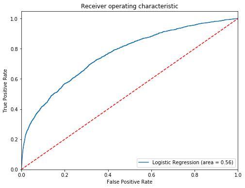

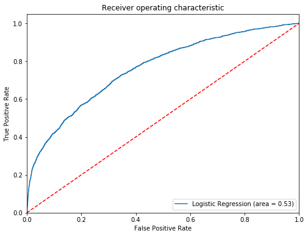

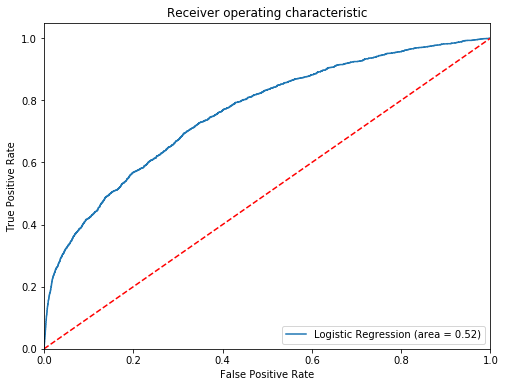

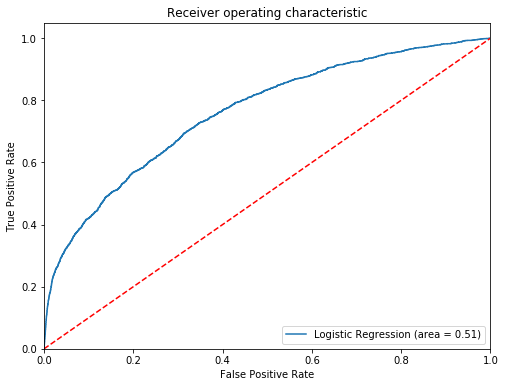

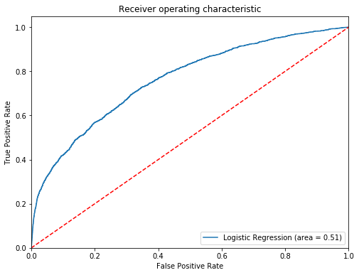

```python
dic = {}
for item in [0.4,0.5,0.6,0.7,0.8]:
    dic[item] = ev.get_roc_auc(y_test, x_test[features[0]], model, res[item])
    print(item)
    print(dic[item])
```

```python
from IPython.display import HTML

HTML('''<script>
code_show=true;
function code_toggle() {
 if (code_show){
 $('div.input').hide();
 } else {
 $('div.input').show();
 }
 code_show = !code_show
}
$( document ).ready(code_toggle);
</script>
<form action="javascript:code_toggle()"><input type="submit" value="Click here to toggle on/off the raw code."></form>''')
```